# Datos de la encuesta TIC en formato abierto

Lab TecnoSocial

8 de mayo de 2020

## 1. Datos abiertos para la toma de decisiones

Los datos abiertos son aquellos “datos que pueden ser utilizados, reutilizados y redistribuidos libremente por cualquier persona”[^1]. Para el tema de políticas públicas, los datos abiertos permiten la participación de actores diferentes a los actores de gobierno. Esto se hace aún más importante en situaciones críticas donde se necesita desarrollar soluciones colectivas sobre problemas complejos, como en la actual crisis por el coronavirus.

Una de los problemas centrales de la presente crisis consiste en compatibilizar la necesidad de guardar distanciamiento para evitar el contagío con la necesidad de realizar nuestras actividad laborales, educativas y sociales. Aquí el Internet juega un factor clave. Pero para ello es necesario saber de antemano en qué situación nos encontramos al respecto para tomar decisiones acertadas.

Sobre el tema de Internet y TIC, en nuestro país, el 2017 el gobierno lanzó una importante encuesta sobre Tecnologías de Información y Comunicación en Bolivia, la primera de su tipo. Un reporte inicial de los resultados se puede encotrar en el portal de la [AGETIC](https://www.agetic.gob.bo/pdf/ResultadosFinalesEncuestaTIC.pdf) y los datos fueron públicados en [repositorio de datos abiertos del Estado](https://datos.gob.bo/dataset/encuesta-nacional-de-opinion-sobre-tic).

Sin embargo, a la hora de procesarlos hemos encontrado varios problemas en el dataset publicado respecto a su formato.

## 2. Problemas con el formato del dataset

Encontramos tres problemas:

- Dificultad de cargar los datos con software libre
- Formato de CSV invalido
- Falta de semántica en sus variables y valores

### 2.1. Cargando el dataset

Descargamos el dataset en formato CSV del [repositorio](https://datos.gob.bo/dataset/encuesta-nacional-de-opinion-sobre-tic) mencionado y realizamos los siguientes intentos de carga.

#### Primer intento con la función `read.csv()` en `R`

Nuestro primer intento con la ya algo anticuada pero todavía confiable función de `read.csv()` en R nos arroja lo siguiente:

```r
base_r <- read.csv("base-5536-bdfinalcorregido.csv")
```

```
Error in read.table(file = file, header = header, sep = sep, quote = quote,  :
  more columns than column names
```

Los datos no cargan y nos produce un error que afirma que existen más columnas que nombres de columnas…

#### Segundo intento con `read_csv()` de la librería `readr` en `R`

Ahora usamos el mucho más joven `read_csv()` que es más rápida y coerciona menos los tipos de datos:

```r
library(readr)
base_r <- read_csv("base-5536-bdfinalcorregido.csv")
```

```
5536 parsing failures.
row col  expected    actual                             file
  1  -- 1 columns 3 columns 'base-5536-bdfinalcorregido.csv'
  2  -- 1 columns 3 columns 'base-5536-bdfinalcorregido.csv'
  3  -- 1 columns 3 columns 'base-5536-bdfinalcorregido.csv'
  4  -- 1 columns 3 columns 'base-5536-bdfinalcorregido.csv'
  5  -- 1 columns 3 columns 'base-5536-bdfinalcorregido.csv'
... ... ......... ......... ................................
See problems(...) for more details.
```

Más alla de los tipos de datos de las columnas que luego pueden especificarse, esta vez los datos cargan. Parece funcionar, aunque con algunas fallas…

Vemos la cabeza de nuestro dataset y nos encontramos con:

```r
head(base_r, 2)
```

| NUMBOL;Tipo;P1;P2;P3;P1A;P1B;P1C;P1D;P1E;P2A;P2B;P2C;P2D;P2E;P3A;P4A;P4;P5;P6;P7A;P7B;P8;P9;P10;P11A;P11B;P11C;P11F;P11G;P11D;P12;P13A;P13B;P14;P15A;P15B;P15C;P15E;P15D;P16;P17;P18;P19;P20;P21A;P21B;P… |
| --- |
| 1;1;18;1;1; ; ; ; ; ; ; ; ; ; ; ; ;2; ;1; ;2;2;3000;2;4;5; ; ; ; ;1; ;4;2500;1;3; ; ; ;1;2;190;4;1; ;3;500;1;150;2;3;2;5;7; ; ; ; ;1; ;5;1000;1;2;3;6; ; ; ; ;1;1;30;4;1; ;1;20;55;1;4;1;2;5; ; ; ; ; ; … |
| 2;1;21;1;1; ; ; ; ; ; ; ; ; ; ; ; ;1;200;1; ;2;1;3800;8;1;2; ; ; ; ;1; ;5;9;1;4; ; ; ;1;1;400;4;1; ;6;800;1;400;6;3;7;10; ; ; ; ; ;1;6;1;1200;1;6;3; ; ; ; ; ;1;1;300;4;1; ;1;100;100;2;5;10;1;2; ; ; ; … |

¡Pesadilla!. Cargó, pero la situción es mucho peor.

Intentemos con Python.

#### Tercer intento con `read_csv()` de la libreria `pandas` de `Python`

A pesar de que hay cierta hostilidad entre las comunidades de R y Python, aquí en el Lab nos llevamos bien con ambos.

```
import pandas as pd
base_p = pd.read_csv("base-5536-bdfinalcorregido.csv")
print(base_p.head(5))
```

[output not shown]

No logró cargar y otra vez error…

#### Solución

Inspeccionando el dataset más de cerca, vemos que el problema es que lleva como delimitador un `;` en vez de `,`. Este pequeño detalle nos ha ocasionado los problemas hasta ahora vistos. Usando la función `read_delim` en `R` o el parametro `sep`en `pandas` logramos cargar los datos.

```r
library(readr)
base_r <- read_delim("base-5536-bdfinalcorregido.csv", delim = ";")
```

```
1850 parsing failures.
 row  col           expected     actual                             file
1067 P98D 1/0/T/F/TRUE/FALSE NINGUNO    'base-5536-bdfinalcorregido.csv'
1071 P83D 1/0/T/F/TRUE/FALSE AEROPUERTO 'base-5536-bdfinalcorregido.csv'
1071 P98D 1/0/T/F/TRUE/FALSE OBJETOS    'base-5536-bdfinalcorregido.csv'
1072 P41F 1/0/T/F/TRUE/FALSE NO USA     'base-5536-bdfinalcorregido.csv'
1086 P42D 1/0/T/F/TRUE/FALSE CASA       'base-5536-bdfinalcorregido.csv'
.... .... .................. .......... ................................
See problems(...) for more details.
```

```r
head(base_r, 5)
```

| NUMBOL | Tipo | P1 | P2 | P3 | P1A | P1B | P1C | P1D | P1E | P2A | P2B | P2C | P2D | P2E | P3A | P4A | P4 | P5 | P6 | P7A | P7B | P8 | P9 | P10 | P11A | P11B | P11C | P11F | P11G | … |
| --- | --- | --- | --- | --- | --- | --- | --- | --- | --- | --- | --- | --- | --- | --- | --- | --- | --- | --- | --- | --- | --- | --- | --- | --- | --- | --- | --- | --- | --- | --- |
| 1 | 1 | 18 | 1 | 1 | NA | NA | NA | NA | NA | NA | NA | NA | NA | NA | NA | NA | 2 | NA | 1 | NA | 2 | 2 | 3000 | 2 | 4 | 5 | NA | NA | NA | … |
| 2 | 1 | 21 | 1 | 1 | NA | NA | NA | NA | NA | NA | NA | NA | NA | NA | NA | NA | 1 | 200 | 1 | NA | 2 | 1 | 3800 | 8 | 1 | 2 | NA | NA | NA | … |
| 3 | 1 | 54 | 1 | 1 | NA | NA | NA | NA | NA | NA | NA | NA | NA | NA | NA | NA | 2 | NA | 2 | NA | NA | NA | NA | 8 | 4 | NA | NA | NA | NA | … |
| 4 | 1 | 30 | 1 | 1 | NA | NA | NA | NA | NA | NA | NA | NA | NA | NA | NA | NA | 2 | NA | 1 | NA | 3 | 1 | 3000 | 3 | 5 | NA | NA | NA | NA | … |
| 5 | 1 | 16 | 1 | 1 | NA | NA | NA | NA | NA | NA | NA | NA | NA | NA | NA | NA | 2 | NA | 2 | NA | NA | NA | NA | 8 | 5 | NA | NA | NA | NA | … |

Ahora con Python:

```
base_p = pd.read_csv("base-5536-bdfinalcorregido.csv", sep=";")
print(base_p.head(5))
```

```
   NUMBOL  Tipo  P1  P2  ... CodP160    Ponderador5536    Ponderador5033 Nse
0       1     1  18   1  ...      33  1,66029585357411  2,55437533673007   3
1       2     1  21   1  ...      33  1,66029585357411  2,55437533673007   4
2       3     1  54   1  ...      33  1,66029585357411  2,55437533673007   2
3       4     1  30   1  ...      33  1,66029585357411  2,55437533673007   2
4       5     1  16   1  ...      33  1,66029585357411  2,55437533673007   2

[5 rows x 451 columns]
```

Si bien es cierto que este problema puede ser trivial para algunos, la idea de los datos abiertos es que tengan la mayor accesibilidad posible y puedan ser inmediatamente utilizados sin mayor problema de acceso. Y para eso deben ser validos, segun estandares y especificaciones.

### 2.2. CSV no valido

Más allá de su solución via parametros adicionales en el código, el problema central tiene que ver con que se ha publicado un CSV no valido. Subiendo este dataset a la herramienta de validación [CSVlint](https://csvlint.io/) del Open Data Institute, confirmamos esta situación:

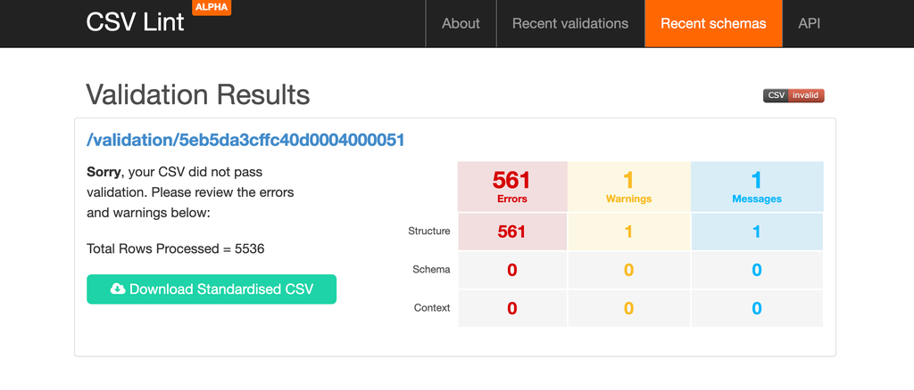

### 2.3. Valores sin semántica

¡Ya lo tenemos cargado! Ahora vamos a analizarlo, ¿qué podría salir mal? Exploremos.

Veamos la estructura del dataset:

```r
str(base_r)
```

```
Classes ‘spec_tbl_df’, ‘tbl_df’, ‘tbl’ and 'data.frame':    5536 obs. of  451 variables:
 $ NUMBOL        : num  1 2 3 4 5 6 7 8 9 10 ...
 $ Tipo          : num  1 1 1 1 1 1 1 1 1 1 ...
 $ P1            : num  18 21 54 30 16 50 40 20 32 18 ...
 $ P2            : num  1 1 1 1 1 1 1 1 1 1 ...
 $ P3            : num  1 1 1 1 1 1 1 1 1 1 ...
 $ P1A           : logi  NA NA NA NA NA NA ...
 $ P1B           : logi  NA NA NA NA NA NA ...
 $ P1C           : logi  NA NA NA NA NA NA ...
 $ P1D           : logi  NA NA NA NA NA NA ...
 $ P1E           : logi  NA NA NA NA NA NA ...
 $ P2A           : logi  NA NA NA NA NA NA ...
 $ P2B           : logi  NA NA NA NA NA NA ...
 $ P2C           : logi  NA NA NA NA NA NA ...
 $ P2D           : logi  NA NA NA NA NA NA ...
 $ P2E           : logi  NA NA NA NA NA NA ...
 $ P3A           : logi  NA NA NA NA NA NA ...
 $ P4A           : logi  NA NA NA NA NA NA ...
 $ P4            : num  2 1 2 2 2 2 2 2 2 1 ...
 $ P5            : num  NA 200 NA NA NA NA NA NA NA 99 ...
 $ P6            : num  1 1 2 1 2 1 2 2 2 1 ...
 $ P7A           : num  NA NA NA NA NA NA NA NA NA 10 ...
 $ P7B           : num  2 2 NA 3 NA 2 NA NA NA NA ...
 $ P8            : num  2 1 NA 1 NA 3 NA NA NA 3 ...
 $ P9            : num  3000 3800 NA 3000 NA 99 NA NA NA 700 ...
 $ P10           : num  2 8 8 3 8 1 9 7 9 7 ...
 $ P11A          : num  4 1 4 5 5 1 NA 4 NA 2 ...
 $ P11B          : num  5 2 NA NA NA NA NA NA NA 3 ...
 $ P11C          : num  NA NA NA NA NA NA NA NA NA 4 ...
 $ P11F          : num  NA NA NA NA NA NA NA NA NA 5 ...
 $ P11G          : num  NA NA NA NA NA NA NA NA NA NA ...
 $ P11D          : chr  NA NA NA NA ...
 $ P12           : num  1 1 1 1 1 1 1 1 1 1 ...
 $ P13A          : num  NA NA NA NA NA NA NA 4 99 10 ...
 $ P13B          : num  4 5 10 5 14 15 17 NA NA NA ...
 $ P14           : num  2500 9 800 1500 9 9 9 1700 1000 2100 ...
 $ P15A          : num  1 1 1 1 4 1 1 1 1 1 ...
 $ P15B          : num  3 4 NA NA 2 2 3 4 4 2 ...
 $ P15C          : num  NA NA NA NA NA 3 NA NA NA 4 ...
 $ P15E          : num  NA NA NA NA NA 4 NA NA NA NA ...
```

[output cut: 506 more lines]

```
  ..   P156F = col_double(),
  ..   P156G = col_double(),
  ..   P156H = col_double(),
  ..   P156I = col_double(),
  ..   P156J = col_double(),
  ..   P156K = col_double(),
  ..   P157 = col_double(),
  ..   P158 = col_double(),
  ..   P159 = col_double(),
  ..   P160 = col_character(),
  ..   CodP160 = col_double(),
  ..   Ponderador5536 = col_character(),
  ..   Ponderador5033 = col_character(),
  ..   Nse = col_double()
  .. )
```

Aquí tenemos un problema de semántica. Las variables no poseen nombres entendibles y los valores tampoco. No podemos hacer preguntas directas a la base de datos, ni siquiera sobre cosas tan básicas como la edad o el sexo. Intentemos con un diagrama de barras de la P3:

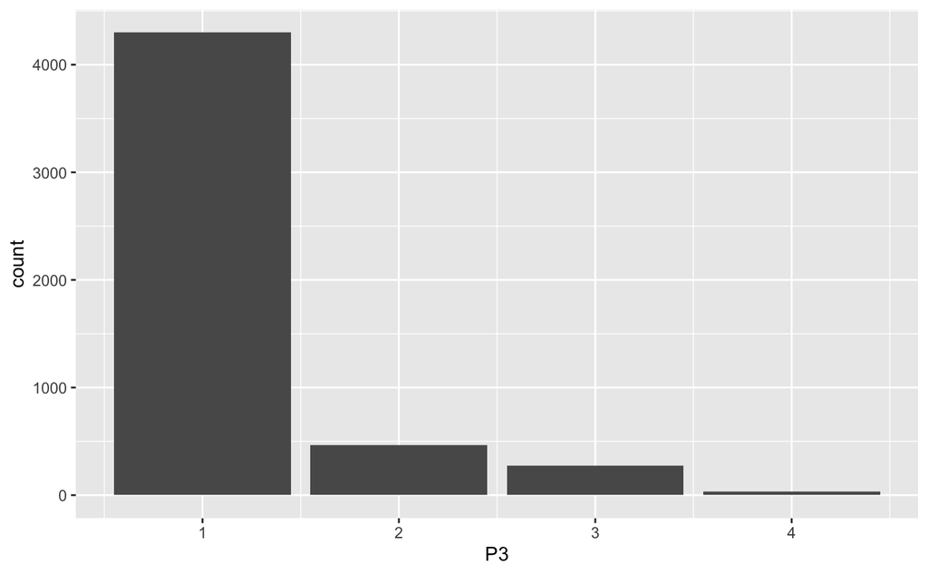

```r
library(ggplot2)
  ggplot(base_r, aes(P3)) +
  geom_bar()
```

La visualización no muestra ni el nombre de la pregunta (solo P3), como tampoco los valores interpretables, (solo 1, 2, 3, 4). Si bien en el repositorio gubernamental se acompaña un diccionario de datos en PDF, este no es directamente utilizable en el procesamiento de los datos y tampoco es un formato abierto. Es necesario contar con las etiquetas de las variables y los valores para poder hacer una mejor interpretación y visualización de los datos.

## 3. Una versión propia, valida y semántica

Hemos dado una solución a los problemas de (1) validación de formato, que llevan a problemas en el cargado de los mismos, y (2) a la semántica de variables y valores.

Las versiones que subimos a nuestro repositorio son CSV validos:

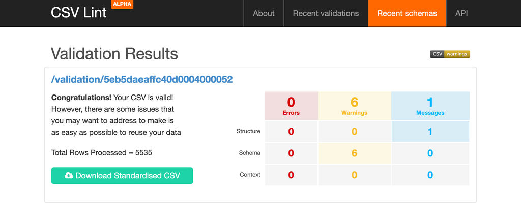

En nuestro repositorio pueden encontrar la misma versión no semántica del CSV publicado por el gobierno, pero con formato CSV Valido (`datos_valores.csv`) y acompañado de dos tablas CSV para las etiquetas de las variables (`etiquetas_variables.csv`) y de los valores (`etiquetas_valores.csv`).

Sobre la semántica damos dos soluciones. La primera es una versión totalmente etiquetada tanto en variables y valores (`datos_etiquetas_todo.csv`). Esta es la versión que se puede usar hacer análisis exploratorio con paquetes como Calc, Excel o Google Sheets. Tiene esta apariencia:

```r
base_etiquetada <- read_csv("csv/eti/datos_etiquetas_todo.csv")
head(base_etiquetada, 5)
```

| Número de Boleta | Tipo de entrevistado | 1. ¿Me podría decir su edad por favor? | 2. ¿Usted ha navegado por Internet o se ha conectado a alguna red social a través de Internet? | 3. ¿Cuándo fue la última vez que navegó en Internet o estuvo conectado a las redes sociales? | 1a. ¿Cuáles son las razones por las cuales no se conecta a Internet regularmente?...6 | 1a. ¿Cuáles son las razones por las cuales no se conecta a Internet regularmente?...7 | 1a. ¿Cuáles son las razones por las cuales no se conecta a Internet regularmente?...8 | 1a. ¿Cuáles son las razones por las cuales no se conecta a Internet regularmente?...9 | 1a. Otro | 2a. En los últimos 6 meses, ¿Ha solicitado a algún conocido que realice en Internet alguna de las siguientes actividades por usted?...11 | 2a. En los últimos 6 meses, ¿Ha solicitado a algún conocido que realice en Internet alguna de las siguientes actividades por usted?...12 | 2a. En los últimos 6 meses, ¿Ha solicitado a algún conocido que realice en Internet alguna de las siguientes actividades por usted?...13 | 2a. En los últimos 6 meses, ¿Ha solicitado a algún conocido que realice en Internet alguna de las siguientes actividades por usted?...14 | 2a. Otro | 3a. ¿Más o menos cuántas veces ha solicitado esta ayuda en el último mes? | 4a. ¿Si tuviera acceso a Internet, usted estaría... ?.... usar Internet? | 4. ¿Tiene teléfono fijo en su casa? | 5. ¿Cuánto pagan al mes por este servicio? | 6. ¿Tiene computadora de escritorio, computadora portátil o tablet en su casa? | 7. ¿Cuándo fue la última vez que en su casa compraron alguno de estos equipos? (MESES) | 7. ¿Cuándo fue la última vez que en su casa compraron alguno de estos equipos? (AÑOS) | 8. Y la última vez ¿Compraron una computadora de escritorio, una computadora portátil o una táblet? | 9. ¿Cuánto pagaron aproximadamente por ese equipo? | 10. ¿Más o menos cuántos días a la semana usa computadora de escritorio, computadora portátil o tablet? | 11. ¿Qué usos le da usted a estos equipos?...26 | 11. ¿Qué usos le da usted a estos equipos?...27 | 11. ¿Qué usos le da usted a estos equipos?...28 | 11. ¿Qué usos le da usted a estos equipos?...29 | 11. ¿Qué usos le da usted a estos equipos?...30 | … |
| --- | --- | --- | --- | --- | --- | --- | --- | --- | --- | --- | --- | --- | --- | --- | --- | --- | --- | --- | --- | --- | --- | --- | --- | --- | --- | --- | --- | --- | --- | --- |
| 1 | INTER | 18 | Si | Hace 7 días o menos | NA | NA | NA | NA | NA | NA | NA | NA | NA | NA | NA | NA | No | NA | Si | NA | 2 | Computadora portátil | 3000 | 2 | Conectarse a Internet | Estudio | NA | NA | NA | … |
| 2 | INTER | 21 | Si | Hace 7 días o menos | NA | NA | NA | NA | NA | NA | NA | NA | NA | NA | NA | NA | Si | 200 | Si | NA | 2 | Computadora de escritorio | 3800 | Menos de una vez por semana | Herramienta de trabajo | Escuchar música o ver videos | NA | NA | NA | … |
| 3 | INTER | 54 | Si | Hace 7 días o menos | NA | NA | NA | NA | NA | NA | NA | NA | NA | NA | NA | NA | No | NA | No | NA | NA | NA | NA | Menos de una vez por semana | Conectarse a Internet | NA | NA | NA | NA | … |
| 4 | INTER | 30 | Si | Hace 7 días o menos | NA | NA | NA | NA | NA | NA | NA | NA | NA | NA | NA | NA | No | NA | Si | NA | 3 | Computadora de escritorio | 3000 | 3 | Estudio | NA | NA | NA | NA | … |
| 5 | INTER | 16 | Si | Hace 7 días o menos | NA | NA | NA | NA | NA | NA | NA | NA | NA | NA | NA | NA | No | NA | No | NA | NA | NA | NA | Menos de una vez por semana | Estudio | NA | NA | NA | NA | … |

```r
NA
```

La segunda es mediante un dataset (`base.csv`) asociado a un diccionario (`dic.csv`), donde las etiquetas del diccionario pueden asociarse con los atributos de los datos mediante R o Python.

En los siguientes días sacaremos reportes de varias dimensiones de Internet y sociedad a partir de estos datos. Pero con los datos abiertos, tú también puedes hacerlo.

[^1]: https://opendatahandbook.org/guide/es/what-is-open-data/